# ProTeomiX (PTX) Quality Control (QC) Report

# 1 Overview

**Quick guide**

- navigate using the ‘Table of Content’ above or just scroll down
- collapse sections by just clicking their name
- click on the “↓ Show Help” symbol to see a description for each metric and its scoring
- edit the config file:///./report_v1.0.9_out_fd2cfec3af2268d2b67e17705e5466.yaml to
  - set the report format (HTML, plainPDF, or both)
  - disable metrics
  - customize the order of metrics
  - set individual target thresholds
- edit file:///./report_v1.0.9_out_fd2cfec3af2268d2b67e17705e5466_filename_sort.txt to customize
  - the order of Raw files in plots and heatmap
  - abbreviations of Raw file names
- edit the Html template file:////opt/conda/envs/nf-core-proteomicslfq-1.1.0dev/lib/R/library/PTXQC/./reportTemplate/PTXQC_report_template.Rmd to
  - alter the look and feel of this report (e.g. colors, font and image sizes, help texts, etc.)
- report bugs and file requests via the [GitHub issue tracker](https://github.com/cbielow/PTXQC/issues)
- full PTXQC manual available [here](https://github.com/cbielow/PTXQC)

## 1.1 HeatMap

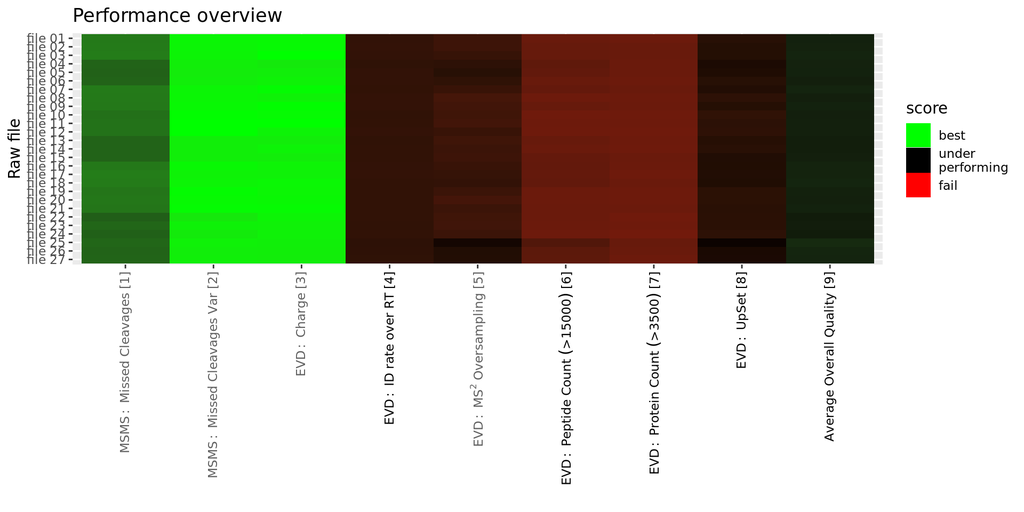

## 1.2 Name Mapping

| Mapping of Raw files to their short names Mapping source: automatic (automatic shortening of names was not sufficient - see ‘best effort’) from | Mapping of Raw files to their short names Mapping source: automatic (automatic shortening of names was not sufficient - see ‘best effort’) to | Mapping of Raw files to their short names Mapping source: automatic (automatic shortening of names was not sufficient - see ‘best effort’) best.effort | Mapping of Raw files to their short names Mapping source: automatic (automatic shortening of names was not sufficient - see ‘best effort’) ms.run |
| --- | --- | --- | --- |
| file:///home/veit/WOMBAT-P/OpenMS-ProteomicsLFQ/Nextflow/no_oxidation/work/2d/8c2f265bfb94cdc26b18bccf3d6ae2/UPS1_12500amol_R1.mzML | file 01 | ..12500am.._R1.mzML | ms_run[1] |
| file:///home/veit/WOMBAT-P/OpenMS-ProteomicsLFQ/Nextflow/no_oxidation/work/2d/8c2f265bfb94cdc26b18bccf3d6ae2/UPS1_12500amol_R2.mzML | file 02 | ..12500am.._R2.mzML | ms_run[2] |
| file:///home/veit/WOMBAT-P/OpenMS-ProteomicsLFQ/Nextflow/no_oxidation/work/2d/8c2f265bfb94cdc26b18bccf3d6ae2/UPS1_12500amol_R3.mzML | file 03 | ..12500am.._R3.mzML | ms_run[3] |
| file:///home/veit/WOMBAT-P/OpenMS-ProteomicsLFQ/Nextflow/no_oxidation/work/2d/8c2f265bfb94cdc26b18bccf3d6ae2/UPS1_125amol_R1.mzML | file 04 | ..125am.._R1.mzML | ms_run[4] |
| file:///home/veit/WOMBAT-P/OpenMS-ProteomicsLFQ/Nextflow/no_oxidation/work/2d/8c2f265bfb94cdc26b18bccf3d6ae2/UPS1_125amol_R2.mzML | file 05 | ..125am.._R2.mzML | ms_run[5] |
| file:///home/veit/WOMBAT-P/OpenMS-ProteomicsLFQ/Nextflow/no_oxidation/work/2d/8c2f265bfb94cdc26b18bccf3d6ae2/UPS1_125amol_R3.mzML | file 06 | ..125am.._R3.mzML | ms_run[6] |
| file:///home/veit/WOMBAT-P/OpenMS-ProteomicsLFQ/Nextflow/no_oxidation/work/2d/8c2f265bfb94cdc26b18bccf3d6ae2/UPS1_25000amol_R1.mzML | file 07 | ..25000am.._R1.mzML | ms_run[7] |
| file:///home/veit/WOMBAT-P/OpenMS-ProteomicsLFQ/Nextflow/no_oxidation/work/2d/8c2f265bfb94cdc26b18bccf3d6ae2/UPS1_25000amol_R2.mzML | file 08 | ..25000am.._R2.mzML | ms_run[8] |
| file:///home/veit/WOMBAT-P/OpenMS-ProteomicsLFQ/Nextflow/no_oxidation/work/2d/8c2f265bfb94cdc26b18bccf3d6ae2/UPS1_25000amol_R3.mzML | file 09 | ..25000am.._R3.mzML | ms_run[9] |
| file:///home/veit/WOMBAT-P/OpenMS-ProteomicsLFQ/Nextflow/no_oxidation/work/2d/8c2f265bfb94cdc26b18bccf3d6ae2/UPS1_2500amol_R1.mzML | file 10 | ..2500am.._R1.mzML | ms_run[10] |
| file:///home/veit/WOMBAT-P/OpenMS-ProteomicsLFQ/Nextflow/no_oxidation/work/2d/8c2f265bfb94cdc26b18bccf3d6ae2/UPS1_2500amol_R2.mzML | file 11 | ..2500am.._R2.mzML | ms_run[11] |
| file:///home/veit/WOMBAT-P/OpenMS-ProteomicsLFQ/Nextflow/no_oxidation/work/2d/8c2f265bfb94cdc26b18bccf3d6ae2/UPS1_2500amol_R3.mzML | file 12 | ..2500am.._R3.mzML | ms_run[12] |
| file:///home/veit/WOMBAT-P/OpenMS-ProteomicsLFQ/Nextflow/no_oxidation/work/2d/8c2f265bfb94cdc26b18bccf3d6ae2/UPS1_250amol_R1.mzML | file 13 | ..250am.._R1.mzML | ms_run[13] |
| file:///home/veit/WOMBAT-P/OpenMS-ProteomicsLFQ/Nextflow/no_oxidation/work/2d/8c2f265bfb94cdc26b18bccf3d6ae2/UPS1_250amol_R2.mzML | file 14 | ..250am.._R2.mzML | ms_run[14] |
| file:///home/veit/WOMBAT-P/OpenMS-ProteomicsLFQ/Nextflow/no_oxidation/work/2d/8c2f265bfb94cdc26b18bccf3d6ae2/UPS1_250amol_R3.mzML | file 15 | ..250am.._R3.mzML | ms_run[15] |
| file:///home/veit/WOMBAT-P/OpenMS-ProteomicsLFQ/Nextflow/no_oxidation/work/2d/8c2f265bfb94cdc26b18bccf3d6ae2/UPS1_50000amol_R1.mzML | file 16 | ..50000am.._R1.mzML | ms_run[16] |
| file:///home/veit/WOMBAT-P/OpenMS-ProteomicsLFQ/Nextflow/no_oxidation/work/2d/8c2f265bfb94cdc26b18bccf3d6ae2/UPS1_50000amol_R2.mzML | file 17 | ..50000am.._R2.mzML | ms_run[17] |
| file:///home/veit/WOMBAT-P/OpenMS-ProteomicsLFQ/Nextflow/no_oxidation/work/2d/8c2f265bfb94cdc26b18bccf3d6ae2/UPS1_50000amol_R3.mzML | file 18 | ..50000am.._R3.mzML | ms_run[18] |
| file:///home/veit/WOMBAT-P/OpenMS-ProteomicsLFQ/Nextflow/no_oxidation/work/2d/8c2f265bfb94cdc26b18bccf3d6ae2/UPS1_5000amol_R1.mzML | file 19 | ..5000am.._R1.mzML | ms_run[19] |
| file:///home/veit/WOMBAT-P/OpenMS-ProteomicsLFQ/Nextflow/no_oxidation/work/2d/8c2f265bfb94cdc26b18bccf3d6ae2/UPS1_5000amol_R2.mzML | file 20 | ..5000am.._R2.mzML | ms_run[20] |
| file:///home/veit/WOMBAT-P/OpenMS-ProteomicsLFQ/Nextflow/no_oxidation/work/2d/8c2f265bfb94cdc26b18bccf3d6ae2/UPS1_5000amol_R3.mzML | file 21 | ..5000am.._R3.mzML | ms_run[21] |
| file:///home/veit/WOMBAT-P/OpenMS-ProteomicsLFQ/Nextflow/no_oxidation/work/2d/8c2f265bfb94cdc26b18bccf3d6ae2/UPS1_500amol_R1.mzML | file 22 | ..500am.._R1.mzML | ms_run[22] |
| file:///home/veit/WOMBAT-P/OpenMS-ProteomicsLFQ/Nextflow/no_oxidation/work/2d/8c2f265bfb94cdc26b18bccf3d6ae2/UPS1_500amol_R2.mzML | file 23 | ..500am.._R2.mzML | ms_run[23] |
| file:///home/veit/WOMBAT-P/OpenMS-ProteomicsLFQ/Nextflow/no_oxidation/work/2d/8c2f265bfb94cdc26b18bccf3d6ae2/UPS1_500amol_R3.mzML | file 24 | ..500am.._R3.mzML | ms_run[24] |
| file:///home/veit/WOMBAT-P/OpenMS-ProteomicsLFQ/Nextflow/no_oxidation/work/2d/8c2f265bfb94cdc26b18bccf3d6ae2/UPS1_50amol_R1.mzML | file 25 | ..50am.._R1.mzML | ms_run[25] |
| file:///home/veit/WOMBAT-P/OpenMS-ProteomicsLFQ/Nextflow/no_oxidation/work/2d/8c2f265bfb94cdc26b18bccf3d6ae2/UPS1_50amol_R2.mzML | file 26 | ..50am.._R2.mzML | ms_run[26] |
| file:///home/veit/WOMBAT-P/OpenMS-ProteomicsLFQ/Nextflow/no_oxidation/work/2d/8c2f265bfb94cdc26b18bccf3d6ae2/UPS1_50amol_R3.mzML | file 27 | ..50am.._R3.mzML | ms_run[27] |

## 1.3 Metrics

### 1.3.1 PAR: parameters

↓ Show Help

MaxQuant parameters, extracted from parameters.txt (abbreviated as ‘PAR’), summarizes the settings used for the MaxQuant analysis. Key parameters are MaxQuant version, Re-quantify, Match-between-runs and mass search tolerances. A list of protein database files is also provided, allowing to track database completeness and database version information (if given in the filename).

| yeast_UPS_decoy parameter | yeast_UPS_decoy value | yeast_UPS_decoy parameter | yeast_UPS_decoy value |
| --- | --- | --- | --- |
| assay[1]-ms_run_ref | ms_run[1] | peptide_search_engine_score[.. | [MS, MS:1003114, OpenMS:Best PSM Score, ] |
| assay[1]-quantification_reag.. | [MS, MS:1002038, unlabeled sample, ] | peptide-quantification_unit | [, , Abundance, ] |
| assay[10]-ms_run_ref | ms_run[10] | protein_search_engine_score[.. | [MS, MS:1003117, OpenMS:Target-decoy protein q-value, ] |
| assay[11]-ms_run_ref | ms_run[11] | psm_search_engine_score[1] | [, , Percolator MS:1001493, ] |
| assay[12]-ms_run_ref | ms_run[12] | quantification_method | [MS, MS:1001834, LC-MS label-free quantitation analysis, ] |
| assay[13]-ms_run_ref | ms_run[13] | software[1] | [MS, MS:1000752, TOPP software, 2.6.0-pre-develop-2021-06-08] |
| assay[14]-ms_run_ref | ms_run[14] | software[2] | [MS, MS:1002203, TOPP ProteinInference, 2.6.0-pre-develop-2021-06-08] |
| assay[15]-ms_run_ref | ms_run[15] | software[3] | [MS, MS:1001490, Percolator, 3.05] |
| assay[16]-ms_run_ref | ms_run[16] | software[3]-setting[1] | peptide_level_fdrs:0 |
| assay[17]-ms_run_ref | ms_run[17] | software[3]-setting[10] | weights:null |
| assay[18]-ms_run_ref | ms_run[18] | software[3]-setting[11] | init_weights:null |
| assay[19]-ms_run_ref | ms_run[19] | software[3]-setting[12] | default_direction:null |
| assay[2]-ms_run_ref | ms_run[2] | software[3]-setting[13] | cpos:0.0 |
| assay[20]-ms_run_ref | ms_run[20] | software[3]-setting[14] | cneg:0.0 |
| assay[21]-ms_run_ref | ms_run[21] | software[3]-setting[15] | unitnorm:0 |
| assay[22]-ms_run_ref | ms_run[22] | software[3]-setting[16] | override:0 |
| assay[23]-ms_run_ref | ms_run[23] | software[3]-setting[17] | seed:1 |
| assay[24]-ms_run_ref | ms_run[24] | software[3]-setting[18] | doc:0 |
| assay[25]-ms_run_ref | ms_run[25] | software[3]-setting[19] | klammer:0 |
| assay[26]-ms_run_ref | ms_run[26] | software[3]-setting[2] | protein_level_fdrs:0 |
| assay[27]-ms_run_ref | ms_run[27] | software[3]-setting[20] | fasta:null |
| assay[3]-ms_run_ref | ms_run[3] | software[3]-setting[21] | decoy_pattern:DECOY_ |
| assay[4]-ms_run_ref | ms_run[4] | software[3]-setting[22] | post_processing_tdc:true |
| assay[5]-ms_run_ref | ms_run[5] | software[3]-setting[23] | train_best_positive:0 |
| assay[6]-ms_run_ref | ms_run[6] | software[3]-setting[3] | generic_feature_set:0 |
| assay[7]-ms_run_ref | ms_run[7] | software[3]-setting[4] | testFDR:0.01 |
| assay[8]-ms_run_ref | ms_run[8] | software[3]-setting[5] | trainFDR:0.01 |
| assay[9]-ms_run_ref | ms_run[9] | software[3]-setting[6] | maxiter:10 |
| description | OpenMS export from consensusXML | software[3]-setting[7] | subset_max_train:300000 |
| fixed_mod[1] | [UNIMOD, UNIMOD:4, Carbamidomethyl, ] | software[3]-setting[8] | quick_validation:0 |
| fixed_mod[1]-position | Anywhere | software[3]-setting[9] | static:0 |
| fixed_mod[1]-site | C | study_variable[1]-assay_refs | assay[1] |
| ms_run[1]-format | [MS, MS:1000584, mzML file, ] | study_variable[1]-descriptio.. | no description given |
| ms_run[1]-id_format | [MS, MS:1000768, Thermo nativeID format, ] | study_variable[10]-assay_ref.. | assay[10] |
| ms_run[1]-location | file:///home/veit/WOMBAT-P/OpenMS-ProteomicsLFQ/Nextflow/no_oxidation/work/2d/8c2f265bfb94cdc26b18bccf3d6ae2/UPS1_12500amol_R1.mzML | study_variable[11]-assay_ref.. | assay[11] |
| ms_run[10]-location | file:///home/veit/WOMBAT-P/OpenMS-ProteomicsLFQ/Nextflow/no_oxidation/work/2d/8c2f265bfb94cdc26b18bccf3d6ae2/UPS1_2500amol_R1.mzML | study_variable[12]-assay_ref.. | assay[12] |
| ms_run[11]-location | file:///home/veit/WOMBAT-P/OpenMS-ProteomicsLFQ/Nextflow/no_oxidation/work/2d/8c2f265bfb94cdc26b18bccf3d6ae2/UPS1_2500amol_R2.mzML | study_variable[13]-assay_ref.. | assay[13] |
| ms_run[12]-location | file:///home/veit/WOMBAT-P/OpenMS-ProteomicsLFQ/Nextflow/no_oxidation/work/2d/8c2f265bfb94cdc26b18bccf3d6ae2/UPS1_2500amol_R3.mzML | study_variable[14]-assay_ref.. | assay[14] |
| ms_run[13]-location | file:///home/veit/WOMBAT-P/OpenMS-ProteomicsLFQ/Nextflow/no_oxidation/work/2d/8c2f265bfb94cdc26b18bccf3d6ae2/UPS1_250amol_R1.mzML | study_variable[15]-assay_ref.. | assay[15] |
| ms_run[14]-location | file:///home/veit/WOMBAT-P/OpenMS-ProteomicsLFQ/Nextflow/no_oxidation/work/2d/8c2f265bfb94cdc26b18bccf3d6ae2/UPS1_250amol_R2.mzML | study_variable[16]-assay_ref.. | assay[16] |
| ms_run[15]-location | file:///home/veit/WOMBAT-P/OpenMS-ProteomicsLFQ/Nextflow/no_oxidation/work/2d/8c2f265bfb94cdc26b18bccf3d6ae2/UPS1_250amol_R3.mzML | study_variable[17]-assay_ref.. | assay[17] |
| ms_run[16]-location | file:///home/veit/WOMBAT-P/OpenMS-ProteomicsLFQ/Nextflow/no_oxidation/work/2d/8c2f265bfb94cdc26b18bccf3d6ae2/UPS1_50000amol_R1.mzML | study_variable[18]-assay_ref.. | assay[18] |
| ms_run[17]-location | file:///home/veit/WOMBAT-P/OpenMS-ProteomicsLFQ/Nextflow/no_oxidation/work/2d/8c2f265bfb94cdc26b18bccf3d6ae2/UPS1_50000amol_R2.mzML | study_variable[19]-assay_ref.. | assay[19] |
| ms_run[18]-location | file:///home/veit/WOMBAT-P/OpenMS-ProteomicsLFQ/Nextflow/no_oxidation/work/2d/8c2f265bfb94cdc26b18bccf3d6ae2/UPS1_50000amol_R3.mzML | study_variable[2]-assay_refs | assay[2] |
| ms_run[19]-location | file:///home/veit/WOMBAT-P/OpenMS-ProteomicsLFQ/Nextflow/no_oxidation/work/2d/8c2f265bfb94cdc26b18bccf3d6ae2/UPS1_5000amol_R1.mzML | study_variable[20]-assay_ref.. | assay[20] |
| ms_run[2]-location | file:///home/veit/WOMBAT-P/OpenMS-ProteomicsLFQ/Nextflow/no_oxidation/work/2d/8c2f265bfb94cdc26b18bccf3d6ae2/UPS1_12500amol_R2.mzML | study_variable[21]-assay_ref.. | assay[21] |
| ms_run[20]-location | file:///home/veit/WOMBAT-P/OpenMS-ProteomicsLFQ/Nextflow/no_oxidation/work/2d/8c2f265bfb94cdc26b18bccf3d6ae2/UPS1_5000amol_R2.mzML | study_variable[22]-assay_ref.. | assay[22] |
| ms_run[21]-location | file:///home/veit/WOMBAT-P/OpenMS-ProteomicsLFQ/Nextflow/no_oxidation/work/2d/8c2f265bfb94cdc26b18bccf3d6ae2/UPS1_5000amol_R3.mzML | study_variable[23]-assay_ref.. | assay[23] |
| ms_run[22]-location | file:///home/veit/WOMBAT-P/OpenMS-ProteomicsLFQ/Nextflow/no_oxidation/work/2d/8c2f265bfb94cdc26b18bccf3d6ae2/UPS1_500amol_R1.mzML | study_variable[24]-assay_ref.. | assay[24] |
| ms_run[23]-location | file:///home/veit/WOMBAT-P/OpenMS-ProteomicsLFQ/Nextflow/no_oxidation/work/2d/8c2f265bfb94cdc26b18bccf3d6ae2/UPS1_500amol_R2.mzML | study_variable[25]-assay_ref.. | assay[25] |
| ms_run[24]-location | file:///home/veit/WOMBAT-P/OpenMS-ProteomicsLFQ/Nextflow/no_oxidation/work/2d/8c2f265bfb94cdc26b18bccf3d6ae2/UPS1_500amol_R3.mzML | study_variable[26]-assay_ref.. | assay[26] |
| ms_run[25]-location | file:///home/veit/WOMBAT-P/OpenMS-ProteomicsLFQ/Nextflow/no_oxidation/work/2d/8c2f265bfb94cdc26b18bccf3d6ae2/UPS1_50amol_R1.mzML | study_variable[27]-assay_ref.. | assay[27] |
| ms_run[26]-location | file:///home/veit/WOMBAT-P/OpenMS-ProteomicsLFQ/Nextflow/no_oxidation/work/2d/8c2f265bfb94cdc26b18bccf3d6ae2/UPS1_50amol_R2.mzML | study_variable[3]-assay_refs | assay[3] |
| ms_run[27]-location | file:///home/veit/WOMBAT-P/OpenMS-ProteomicsLFQ/Nextflow/no_oxidation/work/2d/8c2f265bfb94cdc26b18bccf3d6ae2/UPS1_50amol_R3.mzML | study_variable[4]-assay_refs | assay[4] |
| ms_run[3]-location | file:///home/veit/WOMBAT-P/OpenMS-ProteomicsLFQ/Nextflow/no_oxidation/work/2d/8c2f265bfb94cdc26b18bccf3d6ae2/UPS1_12500amol_R3.mzML | study_variable[5]-assay_refs | assay[5] |
| ms_run[4]-location | file:///home/veit/WOMBAT-P/OpenMS-ProteomicsLFQ/Nextflow/no_oxidation/work/2d/8c2f265bfb94cdc26b18bccf3d6ae2/UPS1_125amol_R1.mzML | study_variable[6]-assay_refs | assay[6] |
| ms_run[5]-location | file:///home/veit/WOMBAT-P/OpenMS-ProteomicsLFQ/Nextflow/no_oxidation/work/2d/8c2f265bfb94cdc26b18bccf3d6ae2/UPS1_125amol_R2.mzML | study_variable[7]-assay_refs | assay[7] |
| ms_run[6]-location | file:///home/veit/WOMBAT-P/OpenMS-ProteomicsLFQ/Nextflow/no_oxidation/work/2d/8c2f265bfb94cdc26b18bccf3d6ae2/UPS1_125amol_R3.mzML | study_variable[8]-assay_refs | assay[8] |
| ms_run[7]-location | file:///home/veit/WOMBAT-P/OpenMS-ProteomicsLFQ/Nextflow/no_oxidation/work/2d/8c2f265bfb94cdc26b18bccf3d6ae2/UPS1_25000amol_R1.mzML | study_variable[9]-assay_refs | assay[9] |
| ms_run[8]-location | file:///home/veit/WOMBAT-P/OpenMS-ProteomicsLFQ/Nextflow/no_oxidation/work/2d/8c2f265bfb94cdc26b18bccf3d6ae2/UPS1_25000amol_R2.mzML | title | ConsensusMap export from OpenMS |
| ms_run[9]-location | file:///home/veit/WOMBAT-P/OpenMS-ProteomicsLFQ/Nextflow/no_oxidation/work/2d/8c2f265bfb94cdc26b18bccf3d6ae2/UPS1_25000amol_R3.mzML | variable_mod[1] | [UNIMOD, UNIMOD:1, Acetyl, ] |
| mzTab-mode | Summary | variable_mod[1]-position | Protein N-term |
| mzTab-type | Quantification | variable_mod[1]-site | X |
| mzTab-version | 1.0.0 | NA | NA |

back to top

### 1.3.2 MSMS: Missed cleavages per Raw file

↓ Show Help

Under optimal digestion conditions (high enzyme grade etc.), only few missed cleavages (MC) are expected. In general, increased MC counts also increase the number of peptide signals, thus cluttering the available space and potentially provoking overlapping peptide signals, biasing peptide quantification. Thus, low MC counts should be favored. Interestingly, it has been shown recently that incorporation of peptides with missed cleavages does not negatively influence protein quantification (see [Chiva, C., Ortega, M., and Sabido, E. Influence of the Digestion Technique, Protease, and Missed Cleavage Peptides in Protein Quantitation. J. Proteome Res. 2014, 13, 3979-86](https://pubs.acs.org/doi/abs/10.1021/pr500294d) ). However this is true only if all samples show the same degree of digestion. High missed cleavage values can indicate for example, either a) failed digestion, b) a high (post-digestion) protein contamination, or c) a sample with high amounts of unspecifically degraded peptides which are not digested by trypsin.

If MC>=1 is high (>20%) you should increase the missed cleavages settings in MaxQuant and compare the number of peptides. Usually high MC correlates with bad identification rates, since many spectra cannot be matched to the forward database.

In the rare case that ‘no enzyme’ was specified in MaxQuant, neither scores nor plots are shown.

Heatmap score [MSMS: MC]: the fraction (0% - 100%) of fully cleaved peptides per Raw file

Heatmap score [MSMS: MC Var]: each Raw file is scored for its deviation (score: MedianDist) from the ‘average’ digestion state of the current study.

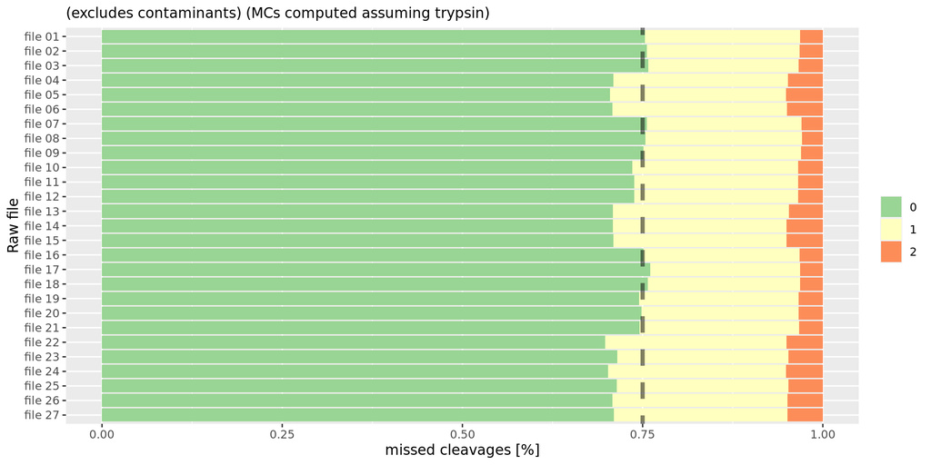

back to top

### 1.3.3 EVD: charge distribution

↓ Show Help

Charge distribution per Raw file. For typtic digests, peptides of charge 2 (one N-terminal and one at tryptic C-terminal R or K residue) should be dominant. Ionization issues (voltage?), in-source fragmentation, missed cleavages and buffer irregularities can cause a shift (see [Bittremieux 2017, DOI: 10.1002/mas.21544](https://onlinelibrary.wiley.com/doi/abs/10.1002/mas.21544) ). The charge distribution should be similar across Raw files. Consistent charge distribution is paramount for comparable 3D-peak intensities across samples.

Heatmap score [EVD: Charge]: Deviation of the charge 2 proportion from a representative Raw file (‘qualMedianDist’ function).

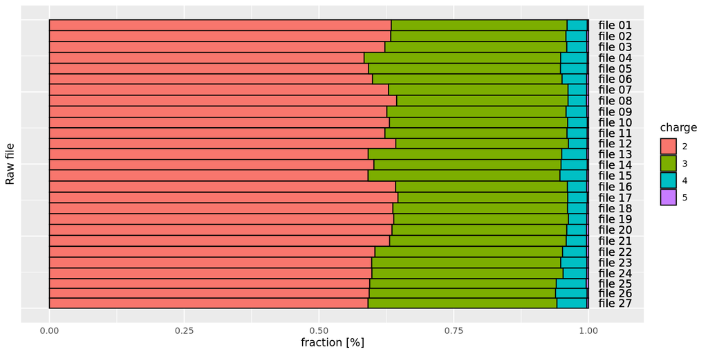

back to top

### 1.3.4 EVD: IDs over RT

↓ Show Help

Judge column occupancy over retention time. Ideally, the LC gradient is chosen such that the number of identifications (here, after FDR filtering) is uniform over time, to ensure consistent instrument duty cycles. Sharp peaks and uneven distribution of identifications over time indicate potential for LC gradient optimization. See [Moruz 2014, DOI: 10.1002/pmic.201400036](https://pubmed.ncbi.nlm.nih.gov/24700534/) for details.

Heatmap score [EVD: ID rate over RT]: Scored using ‘Uniform’ scoring function, i.e. constant receives good score, extreme shapes are bad.

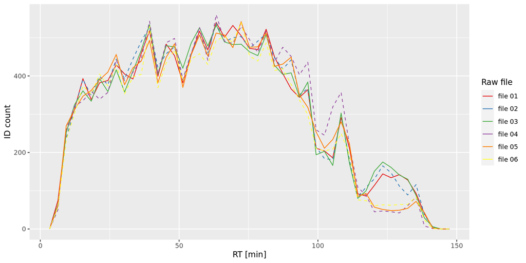

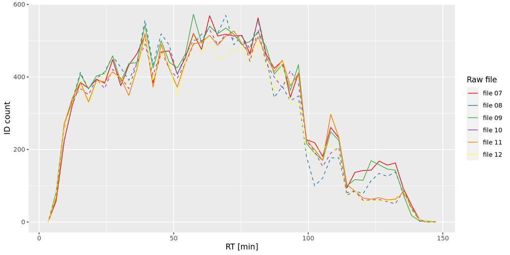

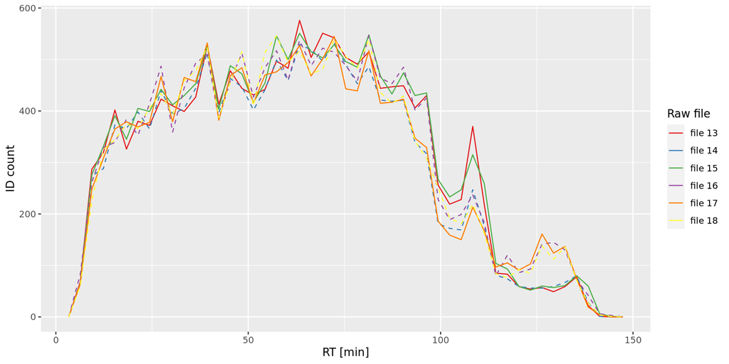

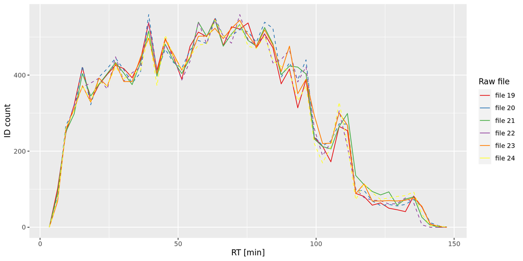

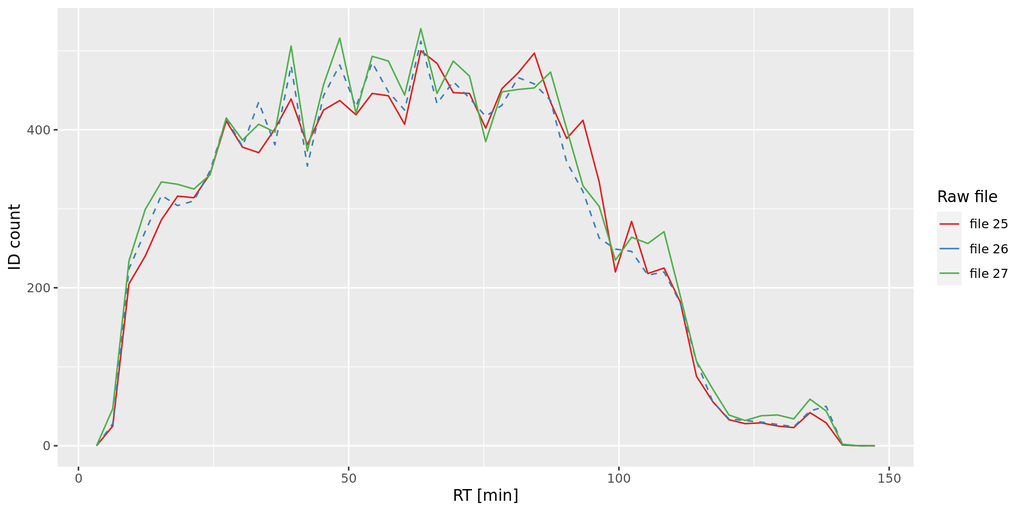

back to top

### 1.3.5 EVD: Oversampling (MS/MS counts per 3D-peak)

↓ Show Help

An oversampled 3D-peak is defined as a peak whose peptide ion (same sequence and same charge state) was identified by at least two distinct MS<sup>2</sup> spectra in the same Raw file. For high complexity samples, oversampling of individual 3D-peaks automatically leads to undersampling or even omission of other 3D-peaks, reducing the number of identified peptides. Oversampling occurs in low-complexity samples or long LC gradients, as well as undersized dynamic exclusion windows for data independent acquisitions.

Heatmap score [EVD: MS<sup>2</sup> Oversampling]: The percentage of non-oversampled 3D-peaks.

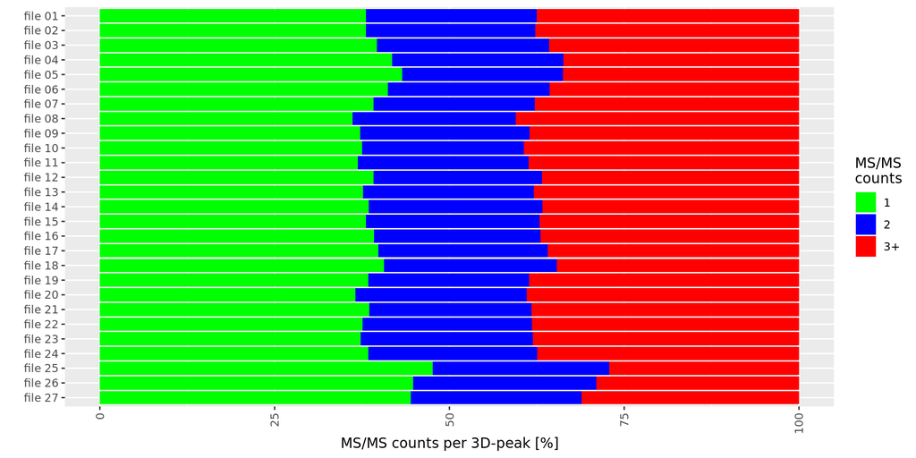

back to top

### 1.3.6 EVD: Peptide ID count

↓ Show Help

Number of unique (i.e. not counted twice) peptide sequences including modifications (after FDR) per Raw file. A configurable target threshold is indicated as dashed line.

If MBR was enabled, three categories (‘genuine (exclusive)’, ‘genuine + transferred’, ‘transferred (exclusive)’ are shown, so the user can judge the gain that MBR provides.  
Peptides in the ‘genuine + transferred’ category were identified within the Raw file by MS/MS, but at the same time also transferred to this Raw file using MBR. This ID transfer can be correct (e.g. in case of different charge states), or incorrect – see MBR-related metrics to tell the difference. Ideally, the ‘genuine + transferred’ category should be rather small, the other two should be large.

If MBR would be switched off, you can expect to see the number of peptides corresponding to ‘genuine (exclusive)’ + ‘genuine + transferred’. In general, if the MBR gain is low and the MBR scores are bad (see the two MBR-related metrics), MBR should be switched off for the Raw files which are affected (could be a few or all).

Heatmap score [EVD: Pep Count (>15000)]: Linear scoring from zero. Reaching or exceeding the target threshold gives a score of 100%.

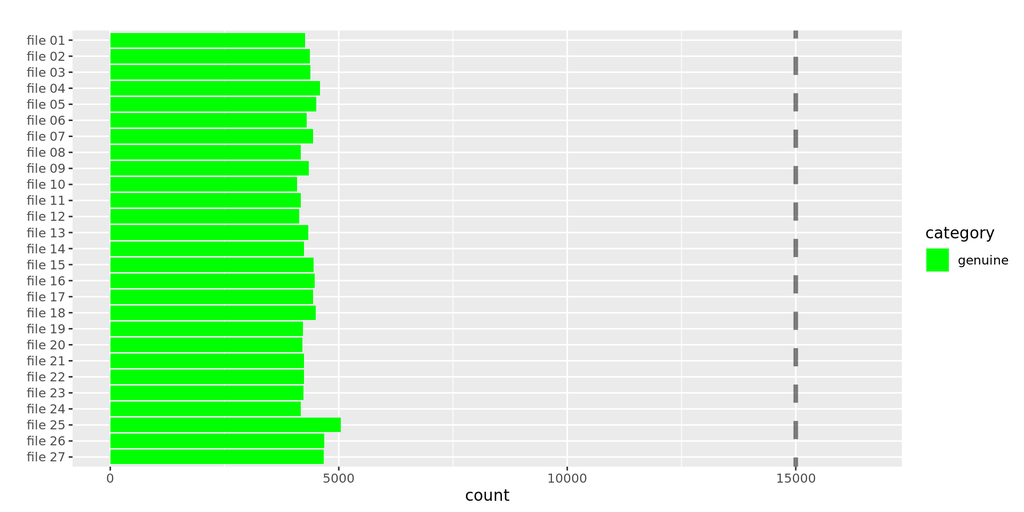

back to top

### 1.3.7 EVD: ProteinGroups count

↓ Show Help

Number of Protein groups (after FDR) per Raw file. A configurable target threshold is indicated as dashed line.

If MBR was enabled, three categories (‘genuine (exclusive)’, ‘genuine + transferred’, ‘transferred (exclusive)’ are shown, so the user can judge the gain that MBR provides. Here, ‘transferred (exclusive)’ means that this protein group has peptide evidence which originates only from transferred peptide IDs. The quantification is (of course) always from the local Raw file. Proteins in the ‘genuine + transferred’ category have peptide evidence from within the Raw file by MS/MS, but at the same time also peptide IDs transferred to this Raw file using MBR were used. It is not unusual to see the ‘genuine + transferred’ category be the rather large, since a protein group usually has peptide evidence from both sources. To see of MBR worked, it is better to look at the two MBR-related metrics.

If MBR would be switched off, you can expect to see the number of protein groups corresponding to ‘genuine (exclusive)’ + ‘genuine + transferred’. In general, if the MBR gain is low and the MBR scores are bad (see the two MBR-related metrics), MBR should be switched off for the Raw files which are affected (could be a few or all).

Heatmap score [EVD: Prot Count (>3500)]: Linear scoring from zero. Reaching or exceeding the target threshold gives a score of 100%.

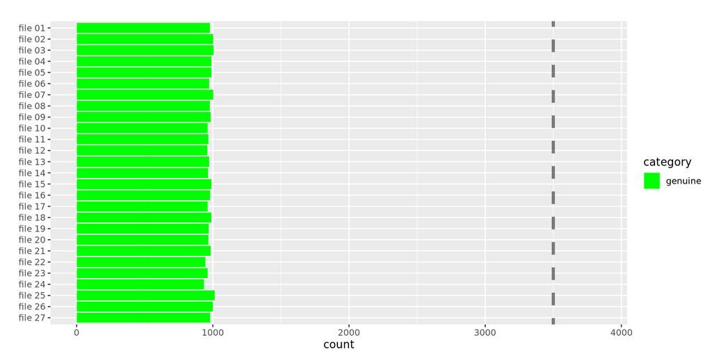

back to top

### 1.3.8 EVD: UpSet distinct

↓ Show Help

The metric shows an upSet plot based on the number of modified peptide sequences per Raw file, intersected or merged with other Raw files (see below for details).

If the number of Raw files is >=6, only the `distinct` plot is generated (the other two are skipped for performance reasons). [See here for an example plot showing how the set size is computed](https://raw.githubusercontent.com/cbielow/PTXQC/master/inst/reportTemplate/modes_UpSet.png) .

Definition: An `active set` is the set of black dots in a column of the plot – as opposed to the grey dots (you will understand when you see it).

**distinct:** shows the number of sequences that are present in ALL active sets. For three Raw files and active sets A and B, this would mean all sequences which occur in A and B (intersect), but not in C (setdiff).  
**intersection:** shows the number of sequences that occurs in all active sets (intersection).  
**union:** shows the number of sequences that occurs in total. For two files that are all sequences that occurs either in A or in B (union).

Heatmap score [EVD: UpSet]: The proportion of sequences that the file has in common with all other files.

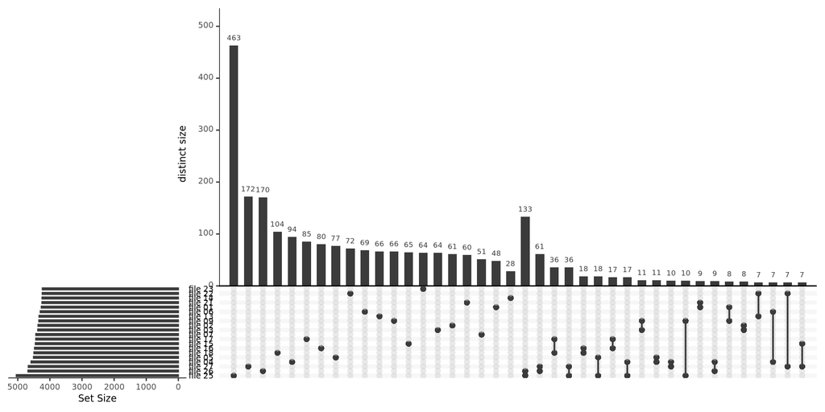

back to top